# Classification

**Serge NYAWA**

October 2022

# Roadmap

- Decision trees algorithm
- Decision trees with R: a case study
- Naïve Bayes algorithm
- Naïve Bayes with R: a case study

# Introductory Example:

A loan company wants to create a set of rules to identify potential defaulters. They have categorical data on 10000 customers concerning: repayement statut (Default or No default. 500 of customers were defaulters); home statut (owner, tenant, other); annual income (<30K, 30-70K, >70K); Age (18-25, 26-40, 41-55, 55+); marital statut (married, divorced, single, widow, other); Criminal Record? (Yes, No); time with employer (<1, 1-5, >5) ; Credit card Owner (Yes, No) (years).

Remark: In the previous example, the attribute “repayement statut”” is the outcome and the others are input variables.

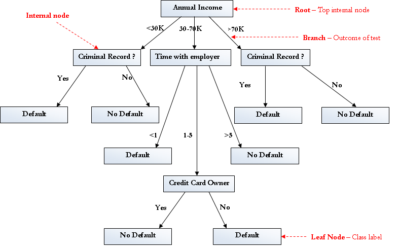

# Objectives

Given historical information about customers, we want:

- To establish a rule whereby we can classify a new customer (on the basis of observed attributes or features) into one of the existing classes (Supervised Learning)
- Prediction based on observed attributes

# Definition

- Entropy: measures the impurity (or absence of information) of an attribute. Given an attribute $X$ and its label $x$, let $P(x)$ be the probability of $x$. The entropy of $X$, $H_X$, is defined as
  $$\begin{aligned}
  H_X=-\sum_{\forall x \in X}P(x)log_2 (P(x))
  \end{aligned}$$
  where $log_2(u)=ln(u)/ln(2)$
- The base entropy: the entropy of the outcome variable;
- The conditional entropy: Given an attribute X, its value x, the outcome variable Y and its value y, the conditional entropy $H_{Y|X}$ is the remaining entropy of Y given X, defined as:
  $$\begin{aligned}
  H_{Y|X}=-\sum_{\forall x \in X}P(x)\sum_{\forall y \in Y} P(y|x)log_2 (P(y|x))
  \end{aligned}$$
- The information gain of an attribute X: the difference between the base entropy $H_Y$ and the conditional entropy of the attribute $H_{Y|X}$
  $$\begin{aligned}
  InfoGain_X=H_Y-H_{Y|X}
  \end{aligned}$$

# Decision trees algorithm: ID3 (Iterative Dichotomiser 3)

Let A be a set of categorical input variables, Y be the output variable (or the predicted class), and T be the training set.

- Step 1: Compute information gain for each attribute in A relative to T
- Step 2: Pick the attribute X with the largest information gain. Let ${x_1,x_2,...,x_m}$ be the values of attribute X
- Partition T into ${T_1,T_2,...,T_m}$ according to the values of X
- Return a tree with root X and branches labeled ${x_1,x_2,...,x_m}$
- Recurse on subsets using remaining attributes: move respectively to trees $ID3(A-{X}, Y, T_1)$, $ID3(A-{X}, Y,T_2)$,…,$ID3(A-{X}, Y, T_m)$

# Decision trees with R: a case study

The data is related with direct marketing campaigns of a Portuguese banking institution. The marketing campaigns were based on phone calls. Often, more than one contact to the same client was required, in order to access if the product (bank term deposit) would be (‘yes’) or not (‘no’) subscribed.

- Attribute Information:
  - Input variables (bank client data): 1-age (numeric); 2-job : type of job (categorical: ‘admin.’,‘blue-collar’,‘entrepreneur’,‘housemaid’,‘management’,‘retired’,‘self-employed’,‘services’,‘student’,‘technician’,‘unemployed’,‘unknown’); 3-marital : marital status (categorical: ‘divorced’,‘married’,‘single’,‘unknown’; note: ‘divorced’ means divorced or widowed); 4-education (categorical: ‘primary’,‘secondary’,‘tertiary’,‘unknown’); 5-default: has credit in default? (categorical: ‘no’,‘yes’,‘unknown’); 6-housing: has housing loan? (categorical: ‘no’,‘yes’,‘unknown’); 7-loan: has personal loan? (categorical: ‘no’,‘yes’,‘unknown’); 8-contact: contact communication type (categorical: ‘cellular’,‘telephone’); 9-month: last contact month of year (categorical: ‘jan’, ‘feb’, ‘mar’, …, ‘nov’, ‘dec’); 10-duration: last contact duration, in seconds (numeric); 11 - campaign: number of contacts performed during this campaign and for this client (numeric, includes last contact); 12-pdays: number of days that passed by after the client was last contacted from a previous campaign (numeric; 999 means client was not previously contacted) 13 - previous: number of contacts performed before this campaign and for this client (numeric); 15-poutcome: outcome of the previous marketing campaign (categorical: ‘failure’,‘nonexistent’,‘success’); 16-day_of_week: last contact day of the week (categorical: ‘mon’,‘tue’,‘wed’,‘thu’,‘fri’).
  - Output variable (desired target): 17-y: has the client subscribed a term deposit? (binary: ‘yes’,‘no’);
- Load the dataset and have a view

```r
Bank_data<-read.csv2("C://Users//s.nyawa//Documents//R for Data Scientist TBS//bank_full.csv")
summary(Bank_data)
```

```
##       age            job              marital           education
##  Min.   :18.00   Length:45211       Length:45211       Length:45211
##  1st Qu.:33.00   Class :character   Class :character   Class :character
##  Median :39.00   Mode  :character   Mode  :character   Mode  :character
##  Mean   :40.94
##  3rd Qu.:48.00
##  Max.   :95.00
##    default             balance         housing              loan
##  Length:45211       Min.   : -8019   Length:45211       Length:45211
##  Class :character   1st Qu.:    72   Class :character   Class :character
##  Mode  :character   Median :   448   Mode  :character   Mode  :character
##                     Mean   :  1362
##                     3rd Qu.:  1428
##                     Max.   :102127
##    contact               day           month              duration
##  Length:45211       Min.   : 1.00   Length:45211       Min.   :   0.0
##  Class :character   1st Qu.: 8.00   Class :character   1st Qu.: 103.0
##  Mode  :character   Median :16.00   Mode  :character   Median : 180.0
##                     Mean   :15.81                      Mean   : 258.2
##                     3rd Qu.:21.00                      3rd Qu.: 319.0
##                     Max.   :31.00                      Max.   :4918.0
##     campaign          pdays          previous          poutcome
##  Min.   : 1.000   Min.   : -1.0   Min.   :  0.0000   Length:45211
##  1st Qu.: 1.000   1st Qu.: -1.0   1st Qu.:  0.0000   Class :character
##  Median : 2.000   Median : -1.0   Median :  0.0000   Mode  :character
##  Mean   : 2.764   Mean   : 40.2   Mean   :  0.5803
##  3rd Qu.: 3.000   3rd Qu.: -1.0   3rd Qu.:  0.0000
##  Max.   :63.000   Max.   :871.0   Max.   :275.0000
##       y
##  Length:45211
##  Class :character
##  Mode  :character
##
##
##
```

- Packages

```
install.packages("rpart.plot")
```

```r
library("rpart")
```

```r
library("rpart.plot")
```

- The rpart function is used to construct a decision tree

```r
decision_tree <- rpart(y ~ job+marital+education+default+housing+
loan+contact+poutcome+duration, method="class", data=Bank_data, control=rpart.control(minsplit=1), parms=list(split="information"))
```

```r
summary(decision_tree)
```

```
## Call:
## rpart(formula = y ~ job + marital + education + default + housing +
##     loan + contact + poutcome + duration, data = Bank_data, method = "class",
##     parms = list(split = "information"), control = rpart.control(minsplit = 1))
##   n= 45211
##
##           CP nsplit rel error    xerror       xstd
## 1 0.02519380      0 1.0000000 1.0000000 0.01292104
## 2 0.02514653      4 0.8992248 0.9548119 0.01266346
## 3 0.02268860      5 0.8740783 0.9126489 0.01241503
## 4 0.01000000      6 0.8513897 0.8642465 0.01211956
##
## Variable importance
## duration poutcome
##       64       36
##
## Node number 1: 45211 observations,    complexity param=0.0251938
##   predicted class=no   expected loss=0.1169848  P(node) =1
##     class counts: 39922  5289
##    probabilities: 0.883 0.117
##   left son=2 (37668 obs) right son=3 (7543 obs)
##   Primary splits:
##       duration < 410.5 to the left,     improve=2051.4570, (0 missing)
##       poutcome splits as  LLRL,         improve=1258.5960, (0 missing)
##       contact  splits as  RRL,          improve= 613.6706, (0 missing)
##       housing  splits as  RL,           improve= 436.4660, (0 missing)
##       job      splits as  LLLLLRLLRLLL, improve= 221.6190, (0 missing)
##
## Node number 2: 37668 observations,    complexity param=0.0251938
##   predicted class=no   expected loss=0.06761708  P(node) =0.8331601
##     class counts: 35121  2547
##    probabilities: 0.932 0.068
##   left son=4 (36493 obs) right son=5 (1175 obs)
##   Primary splits:
##       poutcome splits as  LLRL,         improve=1247.4180, (0 missing)
##       contact  splits as  RRL,          improve= 657.3908, (0 missing)
##       duration < 130.5 to the left,     improve= 646.9845, (0 missing)
##       housing  splits as  RL,           improve= 547.1164, (0 missing)
##       job      splits as  RLLLRRLLRLRR, improve= 242.5992, (0 missing)
##
```

[output cut: 72 more lines]

```
##
## Node number 13: 208 observations
##   predicted class=yes  expected loss=0.2115385  P(node) =0.00460065
##     class counts:    44   164
##    probabilities: 0.212 0.788
##
## Node number 14: 1410 observations
##   predicted class=no   expected loss=0.4269504  P(node) =0.0311871
##     class counts:   808   602
##    probabilities: 0.573 0.427
##
## Node number 15: 1782 observations
##   predicted class=yes  expected loss=0.4186308  P(node) =0.03941519
##     class counts:   746  1036
##    probabilities: 0.419 0.581
```

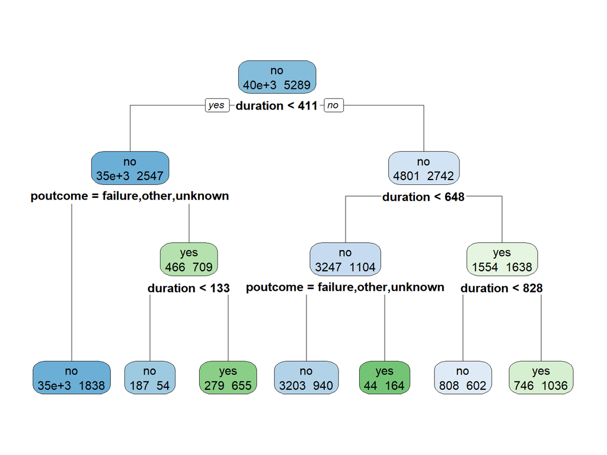

```r
rpart.plot(decision_tree, type=2, extra=1)
```

# Prediction of a new customer

The following features are observed for a new customer: age=35; job=‘entrepreneur’; marital=‘married’; education =‘secondary’; default= ‘no’; housing=‘yes’; loan=‘yes’; contact=‘cellular’; month=‘jan’; duration=523; campaign=2; pdays=26; previous=120; poutcome=‘failure’; day_of_week=17.

We want to predict if this new client will subscribe a term deposit.

```r
new_customer<-data.frame(age=35, job="entrepreneur", marital="married", education ="secondary", default= "no", housing="yes", loan="yes", contact="cellular", month="jan", duration=523, campaign=2, pdays=26, previous=120, poutcome="failure", day_of_week=17)
```

```r
new_customer
```

```
##   age          job marital education default housing loan  contact month
## 1  35 entrepreneur married secondary      no     yes  yes cellular   jan
##   duration campaign pdays previous poutcome day_of_week
## 1      523        2    26      120  failure          17
```

```r
predict(decision_tree,newdata=new_customer,type="class")
```

```
##  1
## no
## Levels: no yes
```

# Naïve Bayes algorithm

It is a classification technique based on Bayes’ Theorem.

Definition: the Bayes’theorem

It provides a way of calculating posterior probability P(C|X) from P(C), P(X) and P(X|C):
$$\begin{aligned}
P(C|X)=\frac{P(X|C)P(C)}{P(X)}
\end{aligned}$$
where

- P(C|X) is the posterior probability of the outcome C given the attributes X
- P(C) is the prior probability of the outcome C
- P(X|C) is the likelihood which is the probability of attributes given the outcome C
- P(X) is the prior probability of attributes

# Naïve Bayes algorithm

- For a new customer with observed attributes *(x1,…,xn)*, the Naïve Bayes algorithm computes the probability to be assigned to a class *ci* given the attributes *(x1,…,xn)*, ie *P(ci|x1,…,xn)*. By the Bayes’ theorem, it is given by

$$\begin{aligned}
P(ci|x_1,...,x_n)=\frac{P(x_1,...,x_n|c_i)P(c_i)}{P(x_1,...,x_n)}
\end{aligned}$$

- The Naïve Bayes algorithm is based on two simplification assumptions:
  - The conditional independence assumption
    $$\begin{aligned}
    P(x_1,...,x_n|c_i)=\Pi_{j=1}^n P(x_j| c_i)
    \end{aligned}$$
  - Ignore the denominator P(x1,…,xn). Then:
    $$\begin{aligned}
    P(ci|x_1,...,x_n)\propto P(c_i). \Pi_{j=1}^n P(x_j| c_i)
    \end{aligned}$$

# Steps of the Naïve Bayes algorithm

- Step1: From the training set, calculate the probabilities of all class labels, *P(ci)*
- Step2: Compute the conditional probabilities of each attribute *xj* given each class label *ci*, namely *P(xj|ci)*
- Step3: For a new record with observed attributes *(x1,…,xn)*, assigns the label *ci* that maximizes

$$\begin{aligned}
P(c_i). \Pi_{j=1}^n P(x_j| c_i)
\end{aligned}$$

# Naïve Bayes with R: Same example than previously

```
install.packages("e1071")
```

```r
library("e1071")
```

- Define the data frames for the Naïve Bayes classifier
  - Discretizing the “duration” variable

```r
 Bank_data$duration2<-ifelse(Bank_data$duration<411,"<411",">411")
```

```r
training_data <- as.data.frame(Bank_data[1:dim(Bank_data)[1]-1,])
test_data <- as.data.frame(Bank_data[dim(Bank_data)[1],])
```

```r
test_data
```

```
##       age          job marital education default balance housing loan  contact
## 45211  37 entrepreneur married secondary      no    2971      no   no cellular
##       day month duration campaign pdays previous poutcome  y duration2
## 45211  17   nov      361        2   188       11    other no      <411
```

- The package “e1071” in R has a built-in naiveBayes function

```r
model <- naiveBayes(y ~ job + marital + education + default + housing +
    loan + contact + poutcome + duration2, training_data)
model
```

```
##
## Naive Bayes Classifier for Discrete Predictors
##
## Call:
## naiveBayes.default(x = X, y = Y, laplace = laplace)
##
## A-priori probabilities:
## Y
##        no       yes
## 0.8830126 0.1169874
##
## Conditional probabilities:
##      job
## Y          admin. blue-collar entrepreneur   housemaid  management     retired
##   no  0.113724606 0.226046442  0.034142431 0.028330954 0.204328549 0.043786478
##   yes 0.119304216 0.133862734  0.023255814 0.020608811 0.245982227 0.097560976
##      job
## Y     self-employed    services     student  technician  unemployed     unknown
##   no    0.034868866 0.094812254 0.016758097 0.169259287 0.027579469 0.006362566
##   yes   0.035356400 0.069767442 0.050860276 0.158820193 0.038192475 0.006428436
##
##      marital
## Y      divorced   married    single
##   no  0.1148518 0.6126600 0.2724882
##   yes 0.1176026 0.5208924 0.3615050
##
##      education
## Y        primary  secondary   tertiary    unknown
##   no  0.15680970 0.51980161 0.28318429 0.04020440
##   yes 0.11174135 0.46322556 0.37738703 0.04764606
##
##      default
## Y              no         yes
##   no  0.980887252 0.019112748
##   yes 0.990168274 0.009831726
##
##      housing
## Y            no       yes
##   no  0.4189775 0.5810225
##   yes 0.6341463 0.3658537
##
##      loan
## Y             no        yes
##   no  0.83066556 0.16933444
##   yes 0.90848932 0.09151068
##
##      contact
## Y       cellular  telephone    unknown
##   no  0.62410761 0.06302447 0.31286791
##   yes 0.82605407 0.07373795 0.10020798
##
##      poutcome
## Y        failure      other    success    unknown
##   no  0.10728689 0.03837579 0.01335137 0.84098595
##   yes 0.11684628 0.05804500 0.18491208 0.64019663
##
##      duration2
## Y          <411      >411
##   no  0.8797375 0.1202625
##   yes 0.4815655 0.5184345
```

- Predict with test_data

```r
results <- predict(model,test_data)
results
```

```
## [1] no
## Levels: no yes
```